# Estadística Descriptiva Multivariada

Análisis de Componentes Principales

Jimmy A Corzo S, PhD

jacorzos@unal.edu.co

Giovany Babativa-Márquez, PhD

jgbabativam@unal.edu.co

# Estadística Descriptiva Multivariada

## Contenido del curso

- Introducción y panorama de los métodos estadísticos multivariados
- Medidas descriptivas multivariadas
- Análisis de componentes principales
- Análisis de correspondencias simples
- Análisis de correspondencias múltiples
- Métodos de agrupamiento (aglomeración)

## Reglas del juego

- Grupo 1:
  - Lunes, 16:00 hrs., Salón 404-208
  - Jueves, 16:00 hrs., Salón 404-208
- Grupo 2:
  - Lunes, 16:00 hrs., Salón 404-206
  - Jueves, 16:00 hrs., Salón 453-405

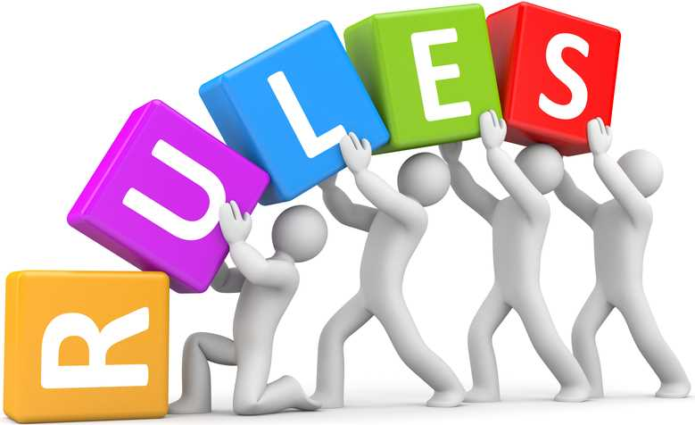

## Evaluación

| Tipo de evaluación | # tareas | Modalidad | % por tarea | % de la nota |
| --- | --- | --- | --- | --- |
| Laboratorios | 4 | En grupo | 6% | 24% |
| Presentación pública* | 2 | En grupo | 8% | 16% |
| Exámenes parciales | 4 | Individual | 15% | 60% |

> *Observación: El hecho de estar en un grupo no da los ocho puntos a todos sus integrantes. Cada integrante debe hacer una parte sustantiva de la presentación para obtenerlos

## Evaluación

- Mecanismo de evaluación:
  - Los exámenes son individuales y se realizan en la sala de cómputo.
  - Los laboratorios se realizan en grupos de 4 personas.

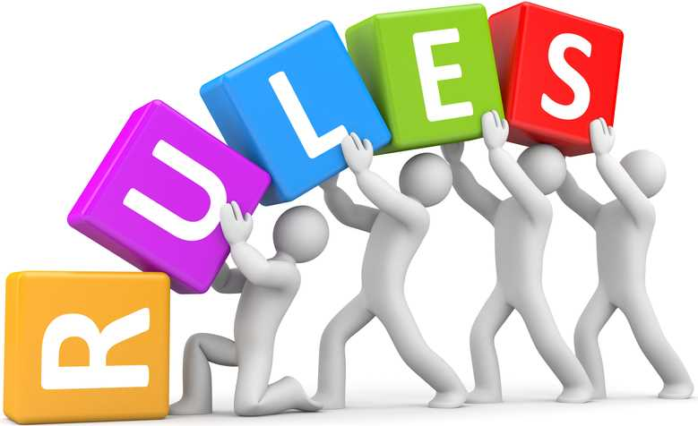

## Temas de cada evaluación y laboratorio

- E1. Introducción, panorama y medidas descriptivas multivariadas.
- E2. Análisis de componentes principales.
- E3. Análisis de correspondencias simples y múltiples.
- E4. Métodos de agrupamiento (aglomeración).

# Blibliografía relevante

- Corzo J. (2026). *Notas de clase*: Introducción al Aprendizaje estadístico no supervisado. [Disponible acá](https://github.com/jgbabativam/Curso_Multivariado/tree/main/Notas%20de%20clase)
- Díaz Monroy, L. G. (2002). Estadística multivariada: inferencia y métodos. [Disponible acá](https://repositorio.unal.edu.co/items/4222e9ea-ba6c-45e0-b719-8108e497cbad)
- Husson, F., Lê, S., & Pagès, J. (2011). Exploratory multivariate analysis by example using R (Vol. 15, pp. 1-60). Boca Raton: CRC press. [Disponible acá](https://api.taylorfrancis.com/content/books/mono/download?identifierName=doi&identifierValue=10.1201/b21874&type=googlepdf)
- Lebart, L., Morineau, A., & Piron, M. (2000). Statistique exploratoire multidimensionnelle. [Disponible acá](https://horizon.documentation.ird.fr/exl-doc/pleins_textes/2022-03/010029478.pdf)
- Pardo, C. E. (2020). Estadística descriptiva multivariada. [Disponible acá](https://repositorio.unal.edu.co/items/283947d9-60fb-478f-a08b-bc6aa13afa6a)

# GRACIAS!

# Citación y derechos de autor

Este material ha sido creado por Jimmy Corzo y [Giovany Babativa-Márquez](https://github.com/jgbabativam) y es de libre distribución bajo la licencia [Creative Commons Attribution-ShareAlike 4.0](https://creativecommons.org/licenses/by-sa/4.0/).

Cualquier copia parcial o total de este material, debe citar la fuente como:

> Corzo J., & Babativa-Márquez, J.G. *Diapositivas del curso de estadística descriptiva multivariada*. URL: https://jgbabativam.github.io/Curso_Multivariado/